# Uncertainty: (how to) deal with it

DSCI 632: Statistics for Data Science

Peter Ralph, University of Oregon

# Course overview

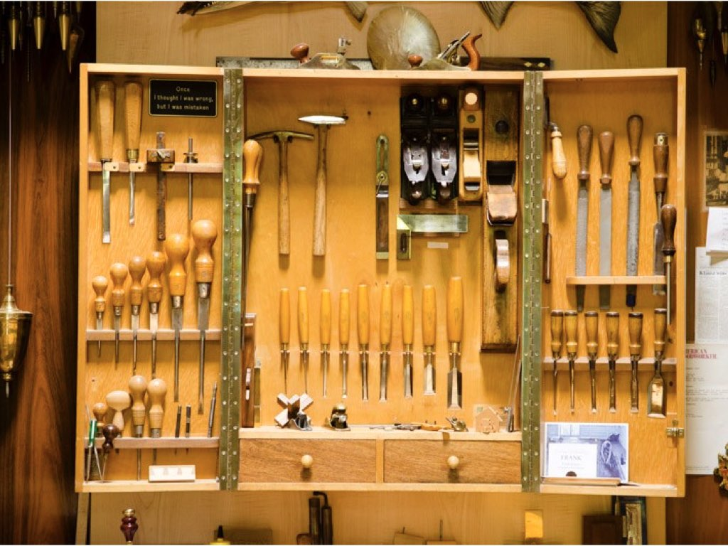

a box of tools

image: Frank Klausz, woodandshop.com

## Steps in data analysis

1. Care, or at least think, about the data.
2. Look at the data.
3. Query the data.
4. Check the results.
5. Communicate.

Often “statistics” focuses on *querying*. Doing that effectively requires all the other steps, too.

## Prerequisites

We’ll be assuming that you have some familiarity with

- programming, and
- statistics

For instance, you should be able to figure out what this means:

```r
x = c(2, 4, 3, 6)
y = c(5, 12, 4, 10, 2)
t.test(x, y)
```

```
##
##  Welch Two Sample t-test
##
## data:  x and y
## t = -1.3761, df = 5.4988, p-value = 0.2222
## alternative hypothesis: true difference in means is not equal to 0
## 95 percent confidence interval:
##  -8.031728  2.331728
## sample estimates:
## mean of x mean of y
##      3.75      6.60
```

## Overview and mechanics

See [the course website](https://uodsci.github.io/ds632).

Please take 10 minutes to

1. answer the “Welcome Survey” on Canvas,
2. get the course repository from github,
3. [install Rstudio](https://rstudio.com/products/rstudio/download/) and/or
4. move around.

# Some core statistical concepts

## Statistics or parameters?

**A **statistic** is**

a numerical description of a dataset.

**A **parameter** is**

a numerical attribute of a model of reality.

Often, *statistics* are used to estimate *parameters*.

## Parameter or statistic?

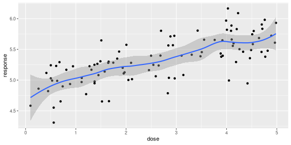

## The two heads of classical statistics

estimating parameters, with uncertainty *(confidence intervals)*

evaluating (in-)consistency with a particular situation *($p$-values)*

1. What do these data tell us about the world?
2. How strongly do we believe it?

*This week:* digging in, with simple examples.

## Lurking, behind everything:

is *uncertainty*

thanks to *randomness*.

How do we understand randomness, concretely and quantitatively?

With *models*.

# A quick look at some data

## Some data

AirBnB hosts in Portland, OR: [data file](https://github.com/UOdsci/ds632/raw/refs/heads/main/datasets/portland-airbnb-listings.csv) (*source*: [website](http://insideairbnb.com/get-the-data.html) and [download link](http://data.insideairbnb.com/united-states/or/portland/2021-07-13/data/listings.csv.gz))

```r
airbnb <- read.csv("../datasets/portland-airbnb-listings.csv")
nrow(airbnb)
```

```
## [1] 5634
```

```r
names(airbnb)
```

```
##   [1] "id"                                           "listing_url"                                  "scrape_id"                                    "last_scraped"
##   [5] "name"                                         "summary"                                      "space"                                        "description"
##   [9] "experiences_offered"                          "neighborhood_overview"                        "notes"                                        "transit"
##  [13] "access"                                       "interaction"                                  "house_rules"                                  "thumbnail_url"
##  [17] "medium_url"                                   "picture_url"                                  "xl_picture_url"                               "host_id"
##  [21] "host_url"                                     "host_name"                                    "host_since"                                   "host_location"
##  [25] "host_about"                                   "host_response_time"                           "host_response_rate"                           "host_acceptance_rate"
##  [29] "host_is_superhost"                            "host_thumbnail_url"                           "host_picture_url"                             "host_neighbourhood"
##  [33] "host_listings_count"                          "host_total_listings_count"                    "host_verifications"                           "host_has_profile_pic"
##  [37] "host_identity_verified"                       "street"                                       "neighbourhood"                                "neighbourhood_cleansed"
##  [41] "neighbourhood_group_cleansed"                 "city"                                         "state"                                        "zipcode"
##  [45] "market"                                       "smart_location"                               "country_code"                                 "country"
##  [49] "latitude"                                     "longitude"                                    "is_location_exact"                            "property_type"
##  [53] "room_type"                                    "accommodates"                                 "bathrooms"                                    "bedrooms"
##  [57] "beds"                                         "bed_type"                                     "amenities"                                    "square_feet"
##  [61] "price"                                        "weekly_price"                                 "monthly_price"                                "security_deposit"
##  [65] "cleaning_fee"                                 "guests_included"                              "extra_people"                                 "minimum_nights"
##  [69] "maximum_nights"                               "minimum_minimum_nights"                       "maximum_minimum_nights"                       "minimum_maximum_nights"
##  [73] "maximum_maximum_nights"                       "minimum_nights_avg_ntm"                       "maximum_nights_avg_ntm"                       "calendar_updated"
##  [77] "has_availability"                             "availability_30"                              "availability_60"                              "availability_90"
##  [81] "availability_365"                             "calendar_last_scraped"                        "number_of_reviews"                            "number_of_reviews_ltm"
##  [85] "first_review"                                 "last_review"                                  "review_scores_rating"                         "review_scores_accuracy"
##  [89] "review_scores_cleanliness"                    "review_scores_checkin"                        "review_scores_communication"                  "review_scores_location"
##  [93] "review_scores_value"                          "requires_license"                             "license"                                      "jurisdiction_names"
##  [97] "instant_bookable"                             "is_business_travel_ready"                     "cancellation_policy"                          "require_guest_profile_picture"
## [101] "require_guest_phone_verification"             "calculated_host_listings_count"               "calculated_host_listings_count_entire_homes"  "calculated_host_listings_count_private_rooms"
## [105] "calculated_host_listings_count_shared_rooms"  "reviews_per_month"
```

Questions: how much does an AirBnB typically cost in Portland? Do “instant bookable” ones cost more?

## Second, look at the data

```r
summary(airbnb$price)
```

```
##    Length  N.unique   N.blank Min.nchar Max.nchar
##      5634       307         0         5         9
```

```r
str(airbnb$price)
```

```
##  chr [1:5634] "$65.00" "$275.00" "$200.00" "$125.00" "$29.00" "$130.00" "$55.00" "$79.00" "$61.00" "$78.00" "$95.00" "$40.00" "$160.00" "$90.00" "$60.00" "$175.00" "$425.00" "$85.00" "$75.00" "$55.00" ...
```

```r
summary(airbnb$instant_bookable)
```

```
##    Length  N.unique   N.blank Min.nchar Max.nchar
##      5634         2         0         1         1
```

```r
str(airbnb$instant_bookable)
```

```
##  chr [1:5634] "f" "t" "f" "f" "t" "t" "f" "t" "f" "f" "f" "t" "f" "f" "f" "f" "f" "t" "f" "t" "t" "f" "f" "f" "f" "f" "f" "f" "t" "f" "f" "t" "f" "t" "t" "f" "f" "t" "f" "t" "f" "f" "f" "f" "f" "t" "f" "f" ...
```

## Fix up those types

```r
airbnb$price <- gsub("$", "", airbnb$price, fixed=TRUE) |> as.numeric()
airbnb$instant_bookable <- (airbnb$instant_bookable == "t")
```

```r
summary(airbnb$price)
```

```
##    Min. 1st Qu.  Median    Mean 3rd Qu.    Max.     NAs
##     0.0    69.0    95.0   119.5   136.0   999.0      32
```

```r
summary(airbnb$instant_bookable)
```

```
##    Mode   FALSE    TRUE
## logical    2960    2674
```

## How much is a typical night?

```r
mean(airbnb$price, na.rm=TRUE)
```

```
## [1] 119.5396
```

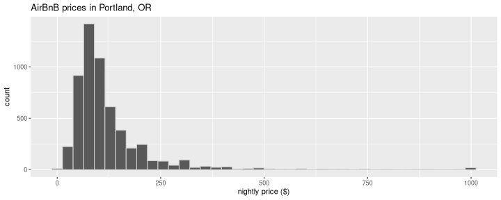

```r
airbnb |> subset(!is.na(price)) |> ggplot(aes(x=price)) +
    geom_histogram(bins=40, col=grey(.8)) +
    labs(x="nightly price ($)", title="AirBnB prices in Portland, OR")
```

Conclusion?

## Do “instant bookable” charge more?

```r
airbnb |> summarize(price=mean(price, na.rm=TRUE), .by=instant_bookable)
```

```
##   instant_bookable    price
## 1            FALSE 114.9668
## 2             TRUE 124.6409
```

## Do “instant bookable” charge more?

[figure not shown]

```r
airbnb |> subset(!is.na(price)) |> ggplot(aes(x=price)) +
    geom_histogram(aes(y=after_stat(density)), bins=50, color=grey(.8)) +
    facet_grid(.~instant_bookable, labeller=label_both) +
    labs(x="nightly price ($)", title="AirBnB prices in Portland, OR")
```

```r
instant <- airbnb$price[airbnb$instant_bookable]
not_instant <- airbnb$price[!airbnb$instant_bookable]
(tt <- t.test(instant, not_instant))
```

```
##
##  Welch Two Sample t-test
##
## data:  instant and not_instant
## t = 3.6482, df = 5039.8, p-value = 0.0002667
## alternative hypothesis: true difference in means is not equal to 0
## 95 percent confidence interval:
##   4.475555 14.872518
## sample estimates:
## mean of x mean of y
##  124.6409  114.9668
```

## Conclusion

> Instant bookable hosts cost more than others (P=0.00027, t-test with df=5039.7695486).

*Critique this conclusion, and write your own.*

*Scribe:* person with the smallest `sample.int(1000, 1)`.

## Don’t forget Steps 1 and 5!

1. Care, or at least think, about the data.
2. Communicate.

How *big* is the difference? How sure are we?

Statistical significance does not imply real-world significance.

## Revised conclusion (in class)

*It’s hard to draw many conclusions from this because we don’t know if this is a representative sample and this isn’t taking into account any covariates, but taking this $t$-test at face value, there appears to be a statistically significant difference between the two groups, of an average difference of around $10 per night.*

So: what did we just do?

“Hypothesis testing and $p$-values”